# fwhm()

## Introduction

In the realm of experimental behavior analysis, most often in timing related research, the Full Width at Half Maximum (FWHM) analysis serves as a metric for quantifying the width of response peaks, particularly in Gaussian-like distributions observed across experimental conditions. FWHM provides a tangible measure to assess the precision, variability, and sensitivity of timing behavior.

Within timing experiments, where datasets often exhibit Gaussian-like distributions with linear components, FWHM analysis becomes a very useful analysis tool. By quantifying peak width, researchers can discern nuanced differences between conditions, assert precision and accuracy, validate theoretical models, and enhance the interpretability of timing data.

The FWHM computes the width of the range of data points in the X axis in which the Y axis values are at least half of the peak value or maximum height. The `fwhm` function takes two parameters:

- `x` a numeric vector of values from a density distribution.
- `y` a numeric vector of probabilities or raw data points.

Returning the *Full Width at Half Maximum* value and the point $x$ at which the max value occurred.

## Example

Lets load a data set from a Peak Procedure session and extract the FWHM and peak values:

```r
data('gauss_example_2', package = "YEAB") #In this case the IF value is 30s.
peak_data <- data
den <- density(peak_data$Response_Average)

fwhm_values <- fwhm(den$x, den$y)

fwhm_values
```

```
## $fwhm
## [1] 1.581608
##
## $peak
## [1] 0.9022719
```

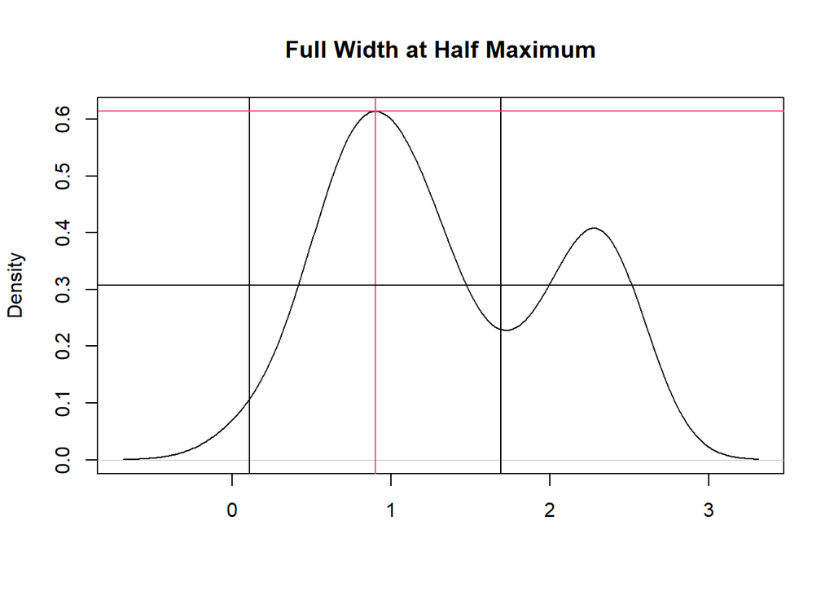